# 9041 Data Viz ‘Bird Sightings at Sea (1969-1990)’

Author

Salomé Carrasco

Published

October 10, 2026

## New Zealand Bird Sightings Across the Sea

## Scientific Article - Version A

### Introduction

Historical observations are vital for future work in the field of conservation and biodiversity for scientists to better understand how the natural world changes in the wake of human influence. In ship logs from Captain John Jekins, estimated numbers of bird observations (flocks) and various behaviors alongside human activities aboard ships are recorded. This work shows the avian and human interactions observed over 21 years (1969-1990). I hypothesize that bird behavior will be influenced by ship activity. I also hypothesize that season will show a significant difference in bird behavior.

### Results

| activity | n |
| --- | --- |
| steaming, sailing | 30446 |
| stationary | 6270 |
| line fishing | 838 |
| trawling | 815 |
| potting | 80 |
| oceanography | 22 |
| flying helicopters | 4 |

Figure 1

In Figure 2 we can see that most of the observations of bird behavior was seen while the ship was sailing, where a majority of behaviors were the birds seen following or flying past the ships. In the two categories with less observations we see less birds following the ship and more accompanying or flying past. We can also see the birds are seen feeding as well during line fishing and trawling.

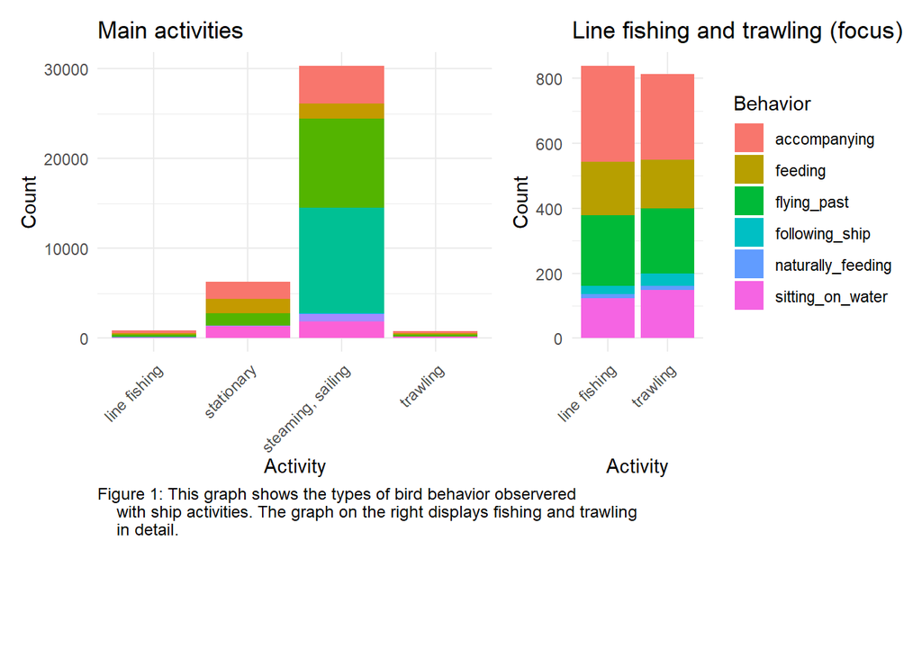

Figure 2

In Figure 3 we see a peak in overall observations of birds flying past in the summer and steep decline in the winter, while in the spring there’s more following the ship in the spring and less in the autumn.

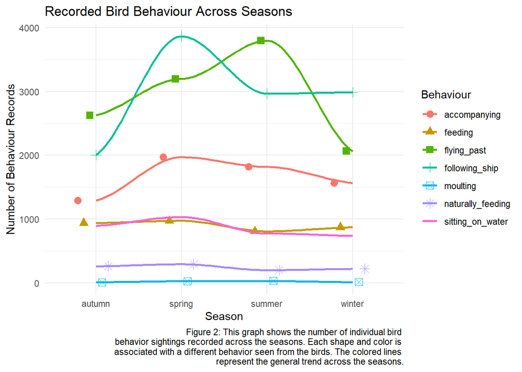

Figure 3

In Figure 4 we see a peak in the numbers of birds of naturally feeding and feeding in the spring. We also see a decline in numbers of birds observed in the winter and autumn in general.

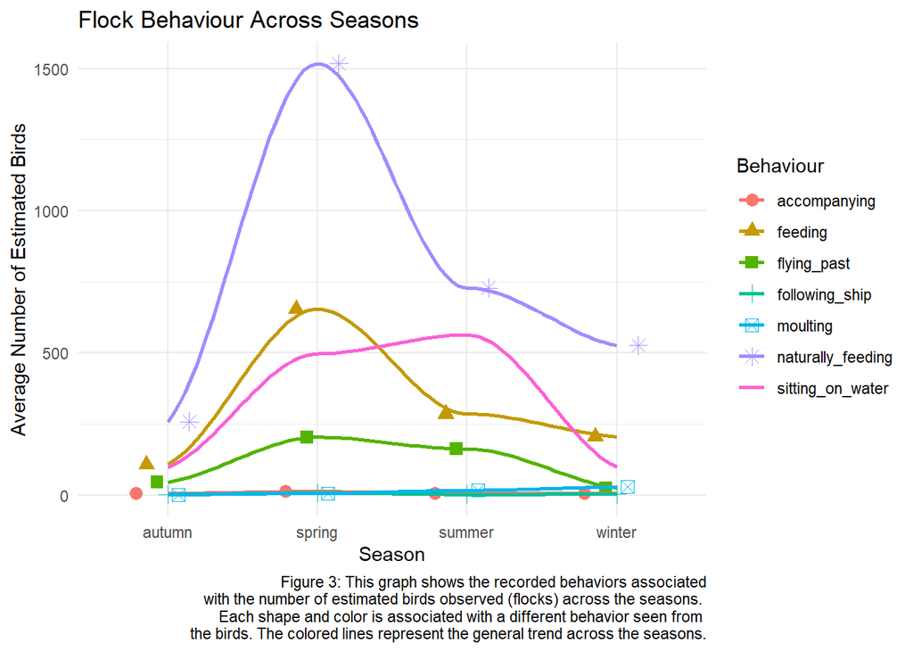

Figure 4

### Conclusion

From this dataset we can see fluctuations in avian behavior across the seasons and during activities on a ship with a trend of feeding increase during the spring and summer and a general observation of birds accompanying ships while fishing. It would be interesting to see more observations of avian behavior around fishing boats from the past and now present.

## Accessible/Dynamic Outlet Article - Version B

### New Zealand Bird Sightings Across the Sea

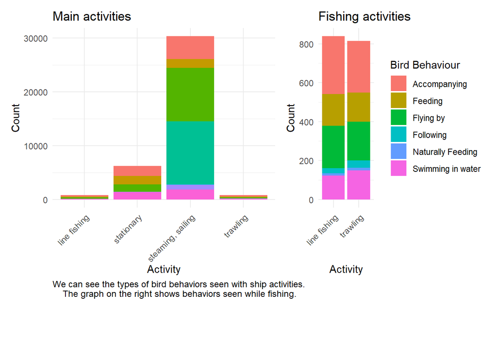

Figure 5

### Southern Ocean bird behavior and ship activity

We see that birds were often seen while the ship was sailing and still on the sea waters. During the times the crew would be fishing we can uncover a little more about what the captain would see when watching the birds. Often times the birds would follow or just fly past the ship while they were sailing. But while the crew was fishing, more birds would stay with the ship and we also see more of them feeding. In this context, feeding means they were most likely feeding on the fish the crew was working on catching. Interestingly they hardly would see the birds naturally feeding. When the ship was still however, we can see an even amount of seen behaviors where they’re feeding, flying past, accompanying the ship, and swimming in the water. Figure 5

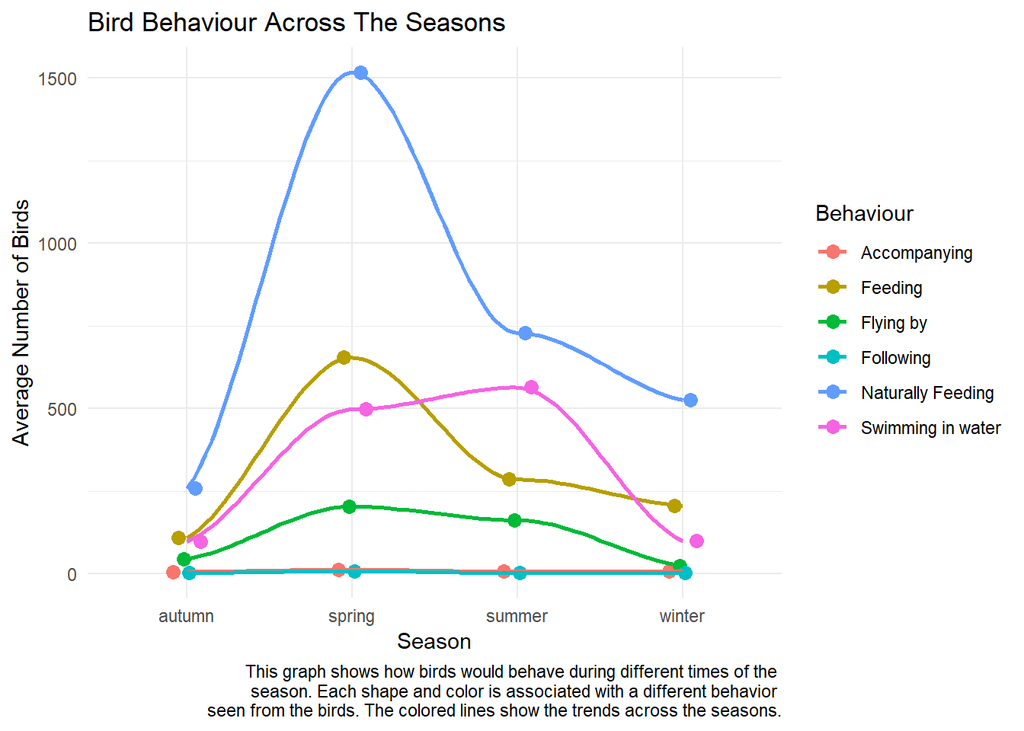

Figure 6

### Seasonal bird behaviors

Each time they would see a species of bird they’d estimate how many they saw, sometimes a few and other times thousands! Over the years, with thousands of birds seen, they were able to track a pattern in the how many birds were present on their journey and with that they also were able to track how the most frequent bird behaviors in the Southern Ocean across the seasons. In the spring a spike of birds would be seen, with an average of 1500 birds naturally feeding along with around 600 birds feeding with the crew, most likely while they drew in the ample fish swimming through the seas. The birds were seen less thereafter with the least seen in the fall. Figure 6

### Closing statement

Long term datasets hold a wealth of knowledge for all interested in the unknown and these logs are no different. We can take records like this and compare it to what we see today. Do we see the same number of birds flying by ships today? Are more birds feeding on food from ships than before? Have their behaviors shifted across the seasons because of climate change? So many questions which can lead to so many solutions. Solutions both in nature and our world as humans. Animal biodiversity can signal to us the health of the local ecosystem and in turn our own environment. Stay curious about the world and what you can uncover.